# **Logistic Regression Analysis**

B.M Njuguna

2022-09-02

# 1.0 Introduction

**Logistic Regression** is used to predict the category or class of individuals using one or multiple predictor variables. Logistic regression estimates the probability of an event occurring, therefore, since the outcome is probability, the dependent variable is bounded between 0 and 1. It is used to predict the outcome of a binary (such as yes or no) based on past values of the data. Logistic regression belongs to the family of **Generalized Linear Models (GLM)** which was built to extend the Linear Regression Model. Logistic Regression is also known as *binary logistic regression* ,*binomial logistic regression* or *logit regression*. The model was initially introduced by Joseph Berkson in 1944. The *response variable* which I will refer as $Y$ in this paper, is parametarized by $0\space or\space 1$. Traditionally, $1$ is indicates a *success* while $0$ indicates a *failure* or *lack of success*. $1$ can also be thought of having a certain characteristic, condition, requirement or property while $0$ can be thought of having certain characteristics or properties. This type of regression is widely used in epidemiological data analysis. For example, we might have a research question such as; *what is the relationship between one or more exposure variable(s) say E to a disease or illness outcome D*. Let us further take an example of smoking habits and Coronary Heart Disease(CHD), where the question is to which extent is CHD related with smoking. Here, $1$ will represent smoker and $0$ non smoker for the case of the independent variable smoking. Also, $1$ will represent *diseased or having CHD* and $0$ will represent *not diseased or not having CHD* , for the case of the response variable.

Other independent variables such as age, race and sex are known as **control variables** ($C_s$) . These control variables together with the binary variables $E_S$ form a collection of independent variables which are used to predict the outcome of the response variable. More generally, as usual, the independent variables are represented with $X$ regardless of whether they are $C_s$ or $E_s$ -*Note that the subscript s is used to represent prural or many variables*. Also, in logistic regression the dependent variable is always a binary outcome.

It is important to note that logistic regression is based on the logistic function below;

$$f(z)=\frac{1}{1+e^{-z}}\space\space
for\space\space -\infty<z<\infty$$

The graph of this function is shown below;

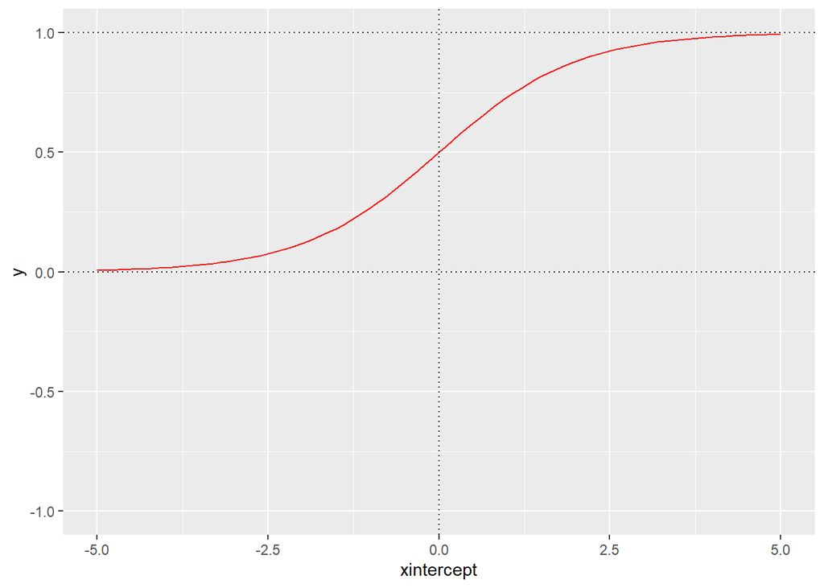

```r
> eq = function(z) {
+     1/(1 + exp(-z))
+ }
> library(ggplot2)
> base <- ggplot() + xlim(-5, 5) + ylim(-1, 1)
> base + geom_function(fun = eq, col = "red") + geom_hline(yintercept = c(0, 1), linetype = "dotted") +
+     geom_vline(xintercept = 0, linetype = "dotted")
```

Notice that for $z=-\infty$, then $f(z)=0$ and for $z=\infty$,then $f(z)=1$. Thus the value of $f(z)$ ranges from zero to one regardless of the value of $z$, which is the primary reason as to why logistic regression is popular. As mentioned earlier, the response variable to be predicted is a probability, and as you know probability ranges from zero to one, hence this model is suitable.

The elongated **S** shape of the function appeals the epidemiologists if $z$ represents an index that combines the contribution of several risk factors and $f(z)$ represents the risk for a given value of $z$. As in most diseases and risk factors, the logistic function shows that at low level exposure, the individual’s risk is minimal until it reaches a certain threshold after which the risk increases rapidly, to a certain threshold also where the risk remains extremely high.

# 1.1 The Logistic Model

To obtain the logistic model, we write $z$ as a linear sum of $x\space\space and \space\space \beta_i$ as follows;

$$z=\beta_0+\beta_1x_1+\beta_2x_2+\dots\beta_nx_n$$

Then, substituting for $z$ in the logistic function above, we get;

$$f(z)=\frac{1}{(1+e^{-(\beta_0+\sum_{i=1}^n\beta_i
x_i)}}$$

Assuming that $D$ is the disease whose probability is being modeled, then we denote $f(z)$ as follows;

$$\mathbb{P}(D|x_1,x_2\dots
x_i)=\frac{1}{(1+e^{-(\beta_0+\sum_{i=1}^n\beta_i x_i)}}$$

By multiplication, it can be shown that;

$$\frac{\mathbb{P}(D)}{1-\mathbb{P}(D)}=e^{(\beta_0+\beta_1x1+\dots+\beta_nx_n)}$$

Taking log on both sides we get;
$$\log(\frac{\mathbb{P}(D)}{1-\mathbb{P}(D)})=\beta_0+\beta_1x_1+\dots+\beta_nx_n$$

The quantity $\log\{\frac{\mathbb{P}(D)}{1-\mathbb{P}(D)}\}$ is known as **log-odd** or the **logit**. The **odd** refer to the likelihood of an event occurring. It can also be seen as the ratio of “success” to “non-success”.

## 1.1.1 Simple Logistic Model

The simple logistic model is used to estimate the probability of class membership based on one predictor or independent variable. The model is written as;

$$\mathbb{P}(D|x_1)=\frac{1}{(1+e^{-(\beta_o+\beta_1x_1)})}$$

To understand this type of regression, let us use an example where let the disease of interest $D$ be $CHD$ or Coronary Heart Disease. We wish to find out whether a certain gender increases the risk of contracting CHD. I am going to use a data set publicly available on *Kaggle*. The data set is from a study of cardiovascular study on residents of the town of Framingham, Massachusetts, which recorded whether the persons in the study contracted CHD.

```r
> ## Importing the data
> setwd("D:/Documents/R-Studio Programms/Regression/Logistic Regression")
> library(readxl)
> CHD <- read_excel("CHD.xlsx")
>
> head(CHD)
```

| Gender | age | currentSmoker | cigsPerDay | Hyp | Chol | BMI | heartRate | glucose | CHD |
| --- | --- | --- | --- | --- | --- | --- | --- | --- | --- |
| 1 | 39 | 0 | 0 | 0 | 195 | 26.97 | 80 | 77 | 0 |
| 0 | 46 | 0 | 0 | 0 | 250 | 28.73 | 95 | 76 | 0 |
| 1 | 48 | 1 | 20 | 0 | 245 | 25.34 | 75 | 70 | 0 |
| 0 | 61 | 1 | 30 | 1 | 225 | 28.58 | 65 | 103 | 1 |
| 0 | 46 | 1 | 23 | 0 | 285 | 23.10 | 85 | 85 | 0 |
| 0 | 43 | 0 | 0 | 1 | 228 | 30.30 | 77 | 99 | 0 |

```r
> ## Data Preparation
> CHD$Gender <- factor(CHD$Gender, levels = c(0, 1), labels = c("Female", "Male"))
> CHD$currentSmoker <- factor(CHD$currentSmoker, levels = c(0, 1), labels = c("No",
+     "Yes"))
> CHD$Hyp <- factor(CHD$Hyp, levels = c(0, 1), labels = c("No", "Yes"))
>
> CHD$CHD <- factor(CHD$CHD, levels = c(0, 1), labels = c("No", "Yes"))
> model1 <- glm(CHD ~ Gender, family = binomial, data = CHD)
> summary(model1)
```

```
##
## Call:
## glm(formula = CHD ~ Gender, family = binomial, data = CHD)
##
## Deviance Residuals:
##     Min       1Q   Median       3Q      Max
## -0.6504  -0.6504  -0.5142  -0.5142   2.0440
##
## Coefficients:
##             Estimate Std. Error z value Pr(>|z|)
## (Intercept) -1.95676    0.06600 -29.647  < 2e-16 ***
## GenderMale   0.51075    0.09058   5.639 1.71e-08 ***
## ---
## Signif. codes:  0 '***' 0.001 '**' 0.01 '*' 0.05 '.' 0.1 ' ' 1
##
## (Dispersion parameter for binomial family taken to be 1)
##
##     Null deviance: 3257.3  on 3799  degrees of freedom
## Residual deviance: 3225.3  on 3798  degrees of freedom
## AIC: 3229.3
##
## Number of Fisher Scoring iterations: 4
```

In logistic model, a negative intercept ($\beta_0$) implies that the probability of having the disease or the outcome is below 0.5. A positive intercept implies that the probability of having the disease or the outcome is greater than 0.5, while an intercept equal to zero implies that the probability is approximately equal to 0.5.

From the output above, our model can be written as;

The probability of CHD infection given that you are a male is;

$$\mathbb{P}(CHD|gender)=\frac{1}{(1+e^{-(-1.957+0.511*1)})}=0.191$$

From the above calculations we can conclude that the risk of having CHD is higher for males than for females. Then if we divide the predicted risk of males by the predicted risk of females as shown below, we obtain the **risk ratio estimate** $\hat{RR}$.

$$\frac{\mathbb{P}(CHD|male)}{\mathbb{P}(CHD|female)}=\frac{0.191}{0.124}=1.540$$

Thus using the the fitted model above we find that risk of males contracting CHD is one and half times the risk of females contracting CHD. More information can be obtained by the summary function in r.

```r
> summary(model1)
```

```
##
## Call:
## glm(formula = CHD ~ Gender, family = binomial, data = CHD)
##
## Deviance Residuals:
##     Min       1Q   Median       3Q      Max
## -0.6504  -0.6504  -0.5142  -0.5142   2.0440
##
## Coefficients:
##             Estimate Std. Error z value Pr(>|z|)
## (Intercept) -1.95676    0.06600 -29.647  < 2e-16 ***
## GenderMale   0.51075    0.09058   5.639 1.71e-08 ***
## ---
## Signif. codes:  0 '***' 0.001 '**' 0.01 '*' 0.05 '.' 0.1 ' ' 1
##
## (Dispersion parameter for binomial family taken to be 1)
##
##     Null deviance: 3257.3  on 3799  degrees of freedom
## Residual deviance: 3225.3  on 3798  degrees of freedom
## AIC: 3229.3
##
## Number of Fisher Scoring iterations: 4
```

The **null deviance** above is a concept in generalized linear models that measures the fitted generalized model against a perfect model known as the **saturated model**. It is a generalization of the total sums of squares in a linear model. The null deviance shows how well the model predicts the response variable with the intercept only. The smaller the Null Deviance, the better the model.

The **residual deviance** shows how well a model can predict the response variable with more than -say $p$- predictors. To determine the usefulness of the model we can calculate a $\chi^2$ statistic with $p$ (number of predictor variables) degrees of freedom as follows; Note that, the lower the value of residual deviance, the better the model (Obviously)

$$\chi^2_{(p)}=Null\space deviance\space
-\space Residual\space deviance$$

After which we find the p-value associated with the statistic, if it is less than $\alpha=0.05$ (for our case), then the model is useful or significant. We only have one predictor variable, thus the degrees of freedom = 1.

$$\chi^2_{(1)}=
3257.3-3225.3=32$$

```r
> pchisq(q = 32, df = 1, lower.tail = F)
```

```
## [1] 1.541726e-08
```

Thus since the p-value is less than $\alpha$, our model is useful.

## 1.1.2 Multiple Logistic Regression

The procedure for multiple logistic regression is the same as for the simple logistic regression. A multiple logistic regression is logistic regression where more than one predictor variables are used to predict the response variable. For example, we may wish to know the effect of age, hypertension, gender, heart rate, smoking habit, BMI level, cholesterol levels and glucose levels on contracting CHD. In r, we build a multiple logistic model as follows;

```r
> model2 <- glm(CHD ~ Gender + age + heartRate + cigsPerDay + Hyp + glucose + Chol +
+     BMI, family = binomial, data = CHD)
> summary(model2)
```

```
##
## Call:
## glm(formula = CHD ~ Gender + age + heartRate + cigsPerDay + Hyp +
##     glucose + Chol + BMI, family = binomial, data = CHD)
##
## Deviance Residuals:
##     Min       1Q   Median       3Q      Max
## -1.9710  -0.6124  -0.4272  -0.2864   2.7772
##
## Coefficients:
##              Estimate Std. Error z value Pr(>|z|)
## (Intercept) -7.836466   0.591433 -13.250  < 2e-16 ***
## GenderMale   0.494717   0.104323   4.742 2.11e-06 ***
## age          0.071724   0.006166  11.631  < 2e-16 ***
## heartRate   -0.001034   0.004091  -0.253   0.8004
## cigsPerDay   0.020985   0.004120   5.094 3.51e-07 ***
## HypYes       0.626856   0.103172   6.076 1.23e-09 ***
## glucose      0.008224   0.001651   4.981 6.33e-07 ***
## Chol         0.002920   0.001060   2.753   0.0059 **
## BMI          0.015999   0.011882   1.346   0.1782
## ---
## Signif. codes:  0 '***' 0.001 '**' 0.01 '*' 0.05 '.' 0.1 ' ' 1
##
## (Dispersion parameter for binomial family taken to be 1)
##
##     Null deviance: 3257.3  on 3799  degrees of freedom
## Residual deviance: 2901.5  on 3791  degrees of freedom
## AIC: 2919.5
##
## Number of Fisher Scoring iterations: 5
```

From the output above, we can see that most predictor variables are significant at $1\%$ level of significance. However, the predictor variables named heartRate and BMI levels are not significant and should be eliminated to increase the accuracy of the model. This elimination can be automatically using statistical techniques, including **step-wise regression** and **penalized regression**.

```r
> model3 <- glm(CHD ~ Gender + age + cigsPerDay + Hyp + glucose + Chol, family = binomial,
+     data = CHD)
> summary(model3)
```

```
##
## Call:
## glm(formula = CHD ~ Gender + age + cigsPerDay + Hyp + glucose +
##     Chol, family = binomial, data = CHD)
##
## Deviance Residuals:
##     Min       1Q   Median       3Q      Max
## -2.0158  -0.6121  -0.4270  -0.2878   2.7786
##
## Coefficients:
##              Estimate Std. Error z value Pr(>|z|)
## (Intercept) -7.517672   0.430433 -17.465  < 2e-16 ***
## GenderMale   0.504079   0.103277   4.881 1.06e-06 ***
## age          0.071662   0.006156  11.642  < 2e-16 ***
## cigsPerDay   0.020410   0.004074   5.010 5.45e-07 ***
## HypYes       0.659169   0.098367   6.701 2.07e-11 ***
## glucose      0.008344   0.001646   5.069 4.00e-07 ***
## Chol         0.002933   0.001057   2.776  0.00551 **
## ---
## Signif. codes:  0 '***' 0.001 '**' 0.01 '*' 0.05 '.' 0.1 ' ' 1
##
## (Dispersion parameter for binomial family taken to be 1)
##
##     Null deviance: 3257.3  on 3799  degrees of freedom
## Residual deviance: 2903.3  on 3793  degrees of freedom
## AIC: 2917.3
##
## Number of Fisher Scoring iterations: 5
```

Thus our model can be written as;

$$\mathbb{P}(CHD|gender,\dots)=\frac{1}{(1+e^{-(-7.518+0.504Gender+0.071Age+0.020CigsPerDay+0.660Hyp+0.008glucose+0.003Cholestrol)})}$$

From the output above, we see that all the $\beta$ coefficients of predictor variables are positive which implies that if any of the predictor variables is increased, the probability of having CHD increases (This applies for the control predictor variables) We can also calculate the odds ratio by taking the exponential of the predictor variables. For example, the $\beta$ coefficient for glucose is $0.008$ which implies that a one unit increase in glucose will increase the odds of having CHD by $e^{0.008}=1.008$ times. Number of iterations is just a measure of how long it took to fit your model and you can safely ignore it.

Note that, we only estimate the Risk Ratio using the logistic regression if a follow up study was conducted. However, in the case of Cross-sectional and case control study, we cannot use the logistic regression to estimate the individual risks but only the odds ratio. In follow-up study, it is commonly preferred to estimate the Risk Ratio rather than the Odds Ratio.

# 2.0 Multinomial Logistic Regression

A **Multinomial Logistic Regression** is an extension of the logistic regression which is used when the outcome involves more than two classes. It allows for more than two categories of the dependent or the independent variable. Multinomial logistic regression is often considered an attractive analysis because it does not assume normality, linearity or homoscedasticity. However, it does have an assumption of independence of choices in the dependent variable which states that the choice of or membership in one category is not related to the choice or membership of another category(IIA). This assumption can be tested using the **Hausman-McFadden test**, in r, we use the function **hmftest**, from **mlogit** package. Given that the categorical response variable $Y$ has more than two possible levels, namely ${1,\dots,J}$ and further given that we have $X_1,X_2,\dots,X_P$, then the multiple logistic regression models the probability of each level $j$ of $Y$, by;

$$p_J(\mathbf{x}):=\mathbb{P}(Y=j|X_1=x_p,\dots,X_p=x_p)=\frac{1}{(1+\sum_{\ell=1}^{J-1}e^{(\beta_{0\ell}+\beta_{1\ell}X_1+\dots+\beta_{p\ell}X_p)}}$$

The multinomial regression has an interesting interpretation of logistic regression. For example taking the quotients;

$$\frac{p_j(\mathbf{x})}{p_J(\mathbf{x})}=
e^{\beta_{0j}+\beta_{1j}X_1+\dots+\beta_{pj}X_p}\space for\space
j=1,\dots,J-1$$

Then taking logarithms on both sides we get;

$$\log{(\frac{p_j(\mathbf{x})}{p_J(\mathbf{x})})}=\beta_{0j}+\beta_{1j}X_1+\dots+\beta_{pj}X_p$$

Thus, if the probabilities on LHS added to one, we would have gotten a log-odds and hence the logistic regression for $Y$, which is not the case. Therefore, due to this effect, we have the *ratios* or the *log-ratios* of the non-complimentary probabilities. Further, $e^{\beta_{0j}}$ is the ratio between $p_j(\mathbf{0})$ and $p_J(\mathbf{0})$, representing the probabilities of $Y=j$ when $X_1=X_2=\dots=X_p=0$.[^1] Note the following;

1. If $e^{\beta_{0j}}>1$ and $\beta_{0j}>0$, then the $Y=j$ is more likely than $Y=J$
2. However, if $e^{\beta_{0j}}<1$ and $\beta_{0j}<0$, then $Y=j$ is less likely than $Y=J$
3. $e^{\beta_{\ell j}}$ is the **multiplicative** increment of the ratio between $p_j(\mathbf{x})$ and $p_J(\mathbf{x})$ for an increment in one unit of $X_\ell=x_\ell$, provided that the remaining variables; $X_1,\dots,X_{\ell-1},X_{\ell+1},\dots,X_p$ do not change.
4. If $e^{\beta_{\ell j}}>1$ and equivalently, $\beta_{\ell j}>0$, then $Y=j$ becomes more likely than $Y=J$ for each increment in $X_j$.
5. if $e^{\beta_{\ell j}}<1$ and $\beta_{\ell j}<00$, then $Y=j$ becomes less likely than $Y=J$ for each increment in $X_j$.

## 2.1 Examples of Multinomial Logistic Regression

1. People’s occupation choices might be influenced by their parents’ occupation and their own educational level. We can model or study the relationship between one’s occupation, educational level and the father’s or mother’s occupation. The outcome or the response variable will be the occupation choices which consists of occupational categories.
2. A biologist may be interested in the food choices an alligator makes. Adult alligators might have different choices from younger ones. Here, the response variable will be the food choices while the predictor variables can be the size of alligators (which is continuous) and other environmental factors.
3. High school students makes a program choice among general program, vocational program and academic program. Their choice might be modeled based on their writing score and social economic status.

In r, there are various packages with inbuilt functions for building a multinomial logistic regression, but am going to use the **nnet package**. Let’s us model the student program choice based on their writing score and social economic status. I’m first going to download the data set known as **hsbdemo** from [stats idre website](https://stats.idre.ucla.edu)

```r
> require(foreign)
> require(nnet)
> require(ggplot2)
> require(reshape2)
>
> ## downloading the data
> Student <- read.dta("https://stats.idre.ucla.edu/stat/data/hsbdemo.dta")
>
> ## A glimpse of the first few rows of the data
> head(Student)
```

|  | id | female | ses | schtyp | prog | read | write | math | science | socst | honors | awards | cid |
| --- | --- | --- | --- | --- | --- | --- | --- | --- | --- | --- | --- | --- | --- |
| 1 | 45 | female | low | public | vocation | 34 | 35 | 41 | 29 | 26 | not enrolled | 0 | 1 |
| 2 | 108 | male | middle | public | general | 34 | 33 | 41 | 36 | 36 | not enrolled | 0 | 1 |
| 3 | 15 | male | high | public | vocation | 39 | 39 | 44 | 26 | 42 | not enrolled | 0 | 1 |
| 4 | 67 | male | low | public | vocation | 37 | 37 | 42 | 33 | 32 | not enrolled | 0 | 1 |
| 5 | 153 | male | middle | public | vocation | 39 | 31 | 40 | 39 | 51 | not enrolled | 0 | 1 |
| 6 | 51 | female | high | public | general | 42 | 36 | 42 | 31 | 39 | not enrolled | 0 | 1 |

The response variable will be the program -named prog in the data set- while the predictor variables will be social economic status -named ses- which is a three-level categorical variable, writing score -named write-a continuous variable.

First, we need to choose our level of outcome that we wish to use as our baseline and then specify this with **relevel** function.

```r
> Student$prog2 <- relevel(Student$prog, ref = "academic")
```

After specifying our baseline level of outcome, We can now use the function **multinom** from the **nnet** package to build the model.

```r
> mlt <- multinom(prog2 ~ ses + write, data = Student)
> summary(mlt)
```

```
## Call:
## multinom(formula = prog2 ~ ses + write, data = Student)
##
## Coefficients:
##          (Intercept)  sesmiddle    seshigh      write
## general     2.852198 -0.5332810 -1.1628226 -0.0579287
## vocation    5.218260  0.2913859 -0.9826649 -0.1136037
##
## Std. Errors:
##          (Intercept) sesmiddle   seshigh      write
## general     1.166441 0.4437323 0.5142196 0.02141097
## vocation    1.163552 0.4763739 0.5955665 0.02221996
##
## Residual Deviance: 359.9635
## AIC: 375.9635
```

The *multinom* function, does not automatically calculate the p-values, hence we will do it manually as follows;

```r
> z <- summary(mlt)$coefficients/summary(mlt)$standard.errors
> z
```

```
##          (Intercept)  sesmiddle   seshigh     write
## general     2.445214 -1.2018081 -2.261334 -2.705562
## vocation    4.484769  0.6116747 -1.649967 -5.112689
```

We can then proceed to calculate the 2-tailed z-test

```r
> p <- (1 - pnorm(abs(z), 0, 1)) * 2
> p
```

```
##           (Intercept) sesmiddle    seshigh        write
## general  0.0144766100 0.2294379 0.02373856 6.818902e-03
## vocation 0.0000072993 0.5407530 0.09894976 3.176045e-07
```

### 2.1.1 Interpretation of the output

The model summary output has a block of coefficients and a block of standard errors. Focusing on the block of coefficients, each row contains a model equation. The first row compares the general program to our baseline academic program while the second row compares the vocation programs to academic program. Let the coefficients from the first row be $\hat{\beta_1}$ and further let coefficients from the second row be $\hat{\beta_2}$, then we can write our model as;

$$\ln(\frac{\mathbb{P}(Program=general)}{\mathbb{P}(Program=academic)})=\hat{\beta_{10}}+\hat{\beta_{11}}(ses=middle)+\hat{\beta_{12}}(ses=high)+\hat{\beta_{13}}write$$

$$\ln(\frac{\mathbb{P}(Program=general)}{\mathbb{P}(Program=academic)})=2.852-0.533(ses=middle)-1.163(ses=high)-0.058write$$

This can be interpreted as:

- A one unit increase in write leads to 0.058 decrease in the log odds of being in general program versus academic program.
- The log odds of being in general program vs academic program decreases by an average of 1.163 if the student has a high social economic status.Or, a high class social economic status student is less likely to be in the general program than to be in the academic program
- The log odds of being in general program vs academic program decreases by 0.533 if the student has a middle social economic status. Or, a middle class social economic status student is less likely to be in the general program than to be in the academic program (although not significant).
- Since our $\hat{\beta_{10}}>0$, then, a student is more likely to be in the general program than to be in the academic program, in the absence of other predictor variables.

Now let the coefficients from the second row be $\hat{\beta_2}$, then we can write the model as;

$$\ln(\frac{\mathbb{P}(Program=vocation)}{\mathbb{P}(Program=academic)})=\hat{\beta_{20}}+\hat{\beta_{21}}(ses=middle)+\hat{\beta_{22}}(ses=high)+\hat{\beta_{23}}write$$

$$\ln(\frac{\mathbb{P}(Program=vocation)}{\mathbb{P}(Program=academic)})=5.219+0/291(ses=middle)-0.983(ses=high)-0.114write$$

This can be interpreted as;

- A one unit increase in write leads to 0.114 decrease in the log odds of being in vocation program versus academic program.
- The log odds of being in vocation program vs academic program decreases by 0.983 if the student has a high class social economic status. Or, a high class social economic status student is less likely to be in the vocation program than to be in the academic program.
- The log odds of being in vocation program vs academic program increases by 0.291 if the student has a middle social economic status. Or, a middle class social economic status student is more likely to be in the vocation program than to be in the academic program (although not statistically significant looking at its p-value).
- Since our $\hat{\beta_{20}}>0$, then, a student is more likely to be in the vocation program than to be in the academic program, in the absence of other predictor variables.

Then the ratio of the probability of choosing one variable outcome over another is called the relative risk. We obtain it by exponentiation of the Right Hand Side of the model.

```r
> exp(coef(mlt))
```

```
##          (Intercept) sesmiddle   seshigh     write
## general     17.32582 0.5866769 0.3126026 0.9437172
## vocation   184.61262 1.3382809 0.3743123 0.8926116
```

### 2.1.2 Assumptions of the Multinomial Logistic Regression

1. The **Independence of the Irrelevant Alternatives (IIA)**- The IIA assumption means that deleting or removing alternative outcome (response) categories does not affect the odds among the remaining outcomes.
2. Sample size- The multinomial logistic regression uses the Maximum Likelihood Estimation method which requires a large sample size. It also uses multiple equations which implies that it requires a larger sample size than what a binary logistic regression would require.
3. Complete or quasi-complete separation- Complete separation means that the outcome variable separate a predictor variable completely, leading perfect prediction by the predictor variable.

You can also use the predicted or estimated probabilities to help you understand your model better as follows;

```r
> head(pp <- fitted(mlt))
```

```
##    academic   general  vocation
## 1 0.1482764 0.3382454 0.5134781
## 2 0.1202017 0.1806283 0.6991700
## 3 0.4186747 0.2368082 0.3445171
## 4 0.1726885 0.3508384 0.4764731
## 5 0.1001231 0.1689374 0.7309395
## 6 0.3533566 0.2377976 0.4088458
```

# 3.0 Ordinal Logistic Regression

Ordinal logistic regression is a statistical analysis method used to model the relationship between an **ordinal response variable** and one or more predictor variable(s). Ordinal data is a type of qualitative type of data with a natural ordered scale e.g the level of income can be low, middle or high. The flowchart below shows the types of data.

```r
> library(DiagrammeR)
> grViz(diagram = "digraph flowchart {
+       # define node aesthetics
+       node [fontname = Arial, shape = rectangle, color = DeepSkyBlue, style = filled]
+       tab1 [label = '@@1']
+       tab2 [label = '@@2']
+       tab3 [label = '@@3']
+       tab4 [label = '@@4']
+       tab5 [label = '@@5']
+       tab6 [label = '@@6']
+       tab7 [label = '@@7']
+ # set up node layout
+       tab1 -> tab2;
+       tab1 -> tab3;
+       tab2 -> tab4;
+       tab2->tab5;
+       tab3->tab6;
+       tab3->tab7
+ }
+
+            [1]:'Data'
+            [2]: 'Categorical/Qualitative Data'
+            [3]: 'Numerical/Quantitative Data'
+            [4]: 'Nominal Data'
+            [5]: 'Ordinal Data'
+            [6]: 'Discrete Data'
+            [7]: 'Continous Data'
+
+       ")
```

[interactive chart not shown]

In r, we can use the **polr** command from **Mass** package to build an Ordinal logistic regression. The command name comes from proportional odds logistic regression.

[^1]: Note that the multinomial regression is like a set of $J-1$ independent logistic regressions for the probability of $Y=j$ versus the probability of reference $Y=J$